# Credit Card Users Churn Prediction

#### OBSERVATIONS

- For Existing Customers: there are outliers (many) above 8K amount.
- For Existing Customers: there no outliers under 1k amount.
- For attrited customers: there are outliers (many) above 5K amount.
- For attrited customers: there is an outlier under above 1K amount.
- Similar attrition rate across tx amounts.

##### Total_Ct_Chng_Q4_Q1 vs Attrition_Flag

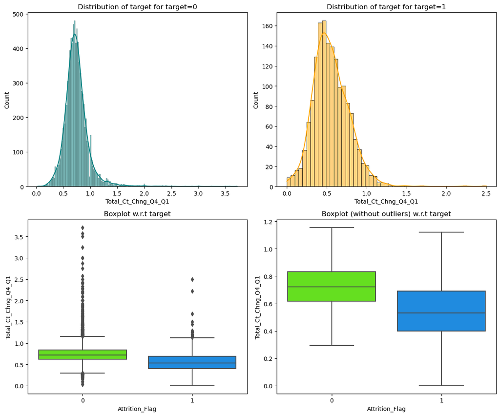

```python
distribution_plot_wrt_target(churn_copy1, "Total_Ct_Chng_Q4_Q1", "Attrition_Flag")
```

#### OBSERVATIONS

- Change in Total_Ct_Chng_Q4_Q1 attrition is bwetween the range 0 - 1.5 and greater than 1.5 is almost nill in both.
- The outliers are there the most for existing customers with Total_Ct_Chng_Q4_Q1 > 1.5 and Total_Ct_Chng_Q4_Q1 < 0.3
- There are outliers for attrited custimers with Total_Ct_Chng_Q4_Q1 > 1.25

###### Avg_Utilization_Ratio vs Attrition_Flag

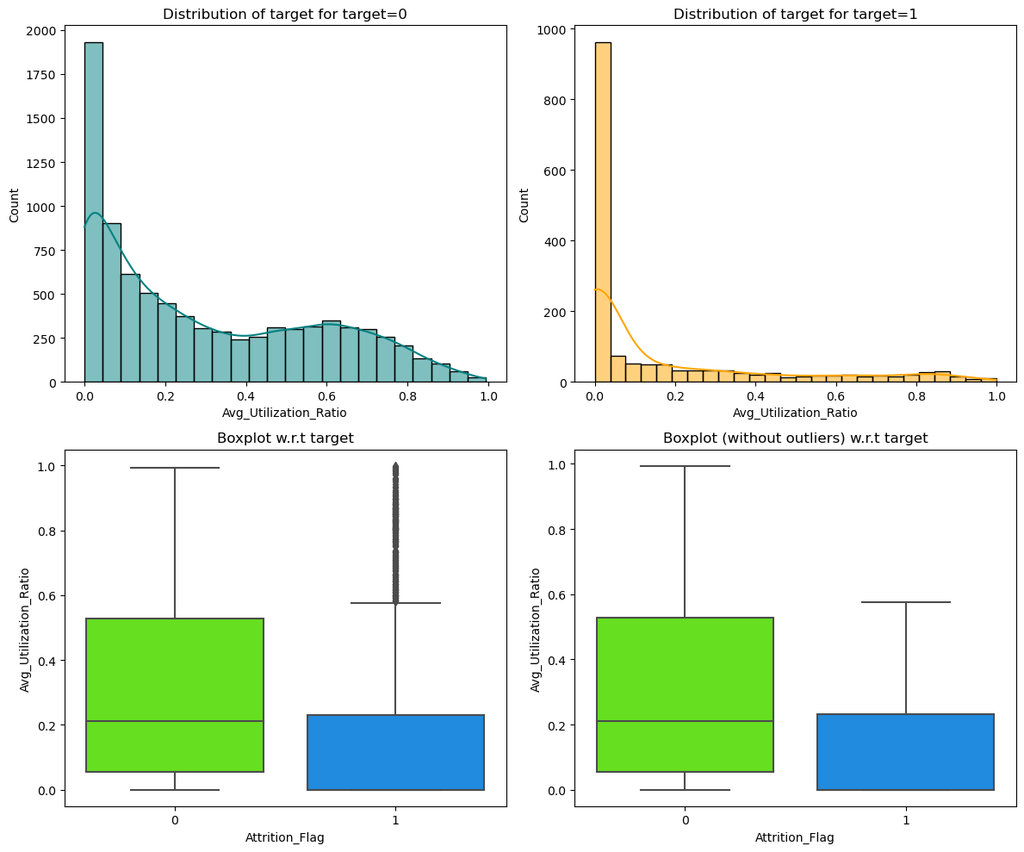

```python
distribution_plot_wrt_target(churn_copy1, "Avg_Utilization_Ratio", "Attrition_Flag")
```

#### OBSERVATIONS

- Too many outliers for attrited customers with Avg_Utilization_Ratio > 0.6
- Attr is more for customers where the Avg_Utilization_Ratio closer to 0

##### Attrition_Flag vs Months_on_book

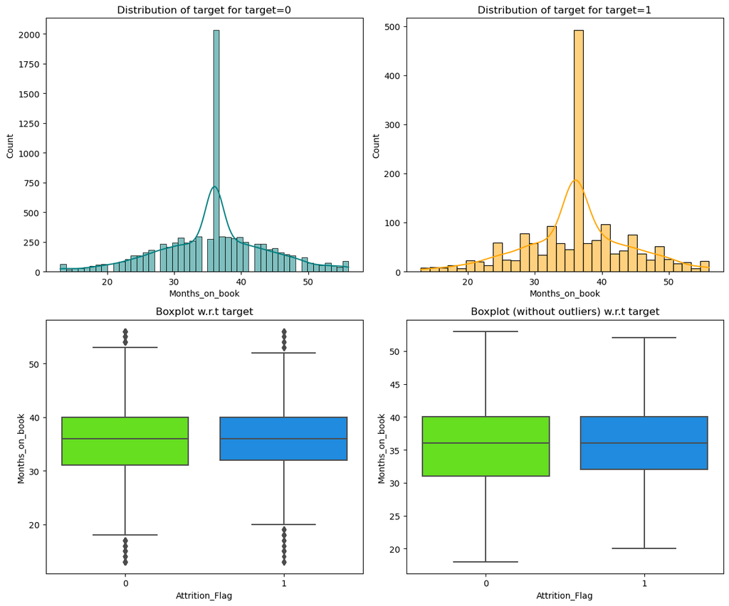

```python
distribution_plot_wrt_target(churn_copy1, "Months_on_book", "Attrition_Flag")
```

#### OBSERVATIONS

##### Attrition_Flag vs Total_Revolving_Bal

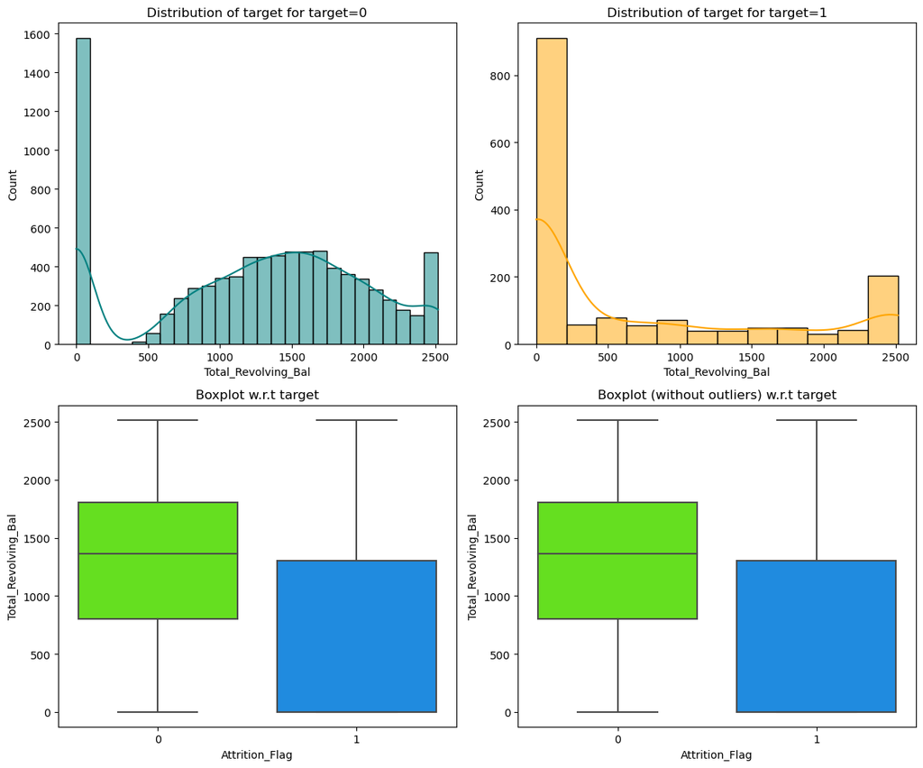

```python
distribution_plot_wrt_target(churn_copy1, "Total_Revolving_Bal", "Attrition_Flag")
```

#### OBSERVATIONS

- No outliers are present for Existing and Attrited customers on the high and low spectrum.
- Lower Total_Revolving_Bal have high attrition (bank to focus)

###### Attrition_Flag vs Avg_Open_To_Buy

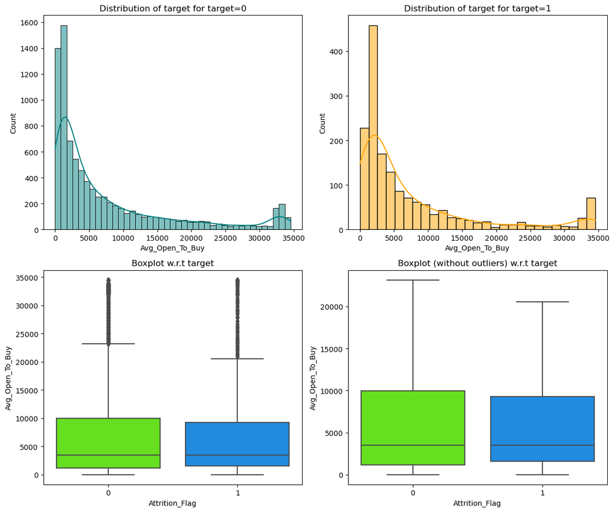

```python
distribution_plot_wrt_target(churn_copy1, "Avg_Open_To_Buy", "Attrition_Flag")
```

#### OBSERVATIONS

```python
churn_copy1.head()
```

|  | Attrition_Flag | Customer_Age | Gender | Dependent_count | Education_Level | Marital_Status | Income_Category | Card_Category | Months_on_book | Total_Relationship_Count | Months_Inactive_12_mon | Contacts_Count_12_mon | Credit_Limit | Total_Revolving_Bal | Avg_Open_To_Buy | Total_Amt_Chng_Q4_Q1 | Total_Trans_Amt | Total_Trans_Ct | Total_Ct_Chng_Q4_Q1 | Avg_Utilization_Ratio |
| --- | --- | --- | --- | --- | --- | --- | --- | --- | --- | --- | --- | --- | --- | --- | --- | --- | --- | --- | --- | --- |
| 0 | 0 | 45 | M | 3 | High School | Married | $60K - $80K | Blue | 39 | 5 | 1 | 3 | 12691.000 | 777 | 11914.000 | 1.335 | 1144 | 42 | 1.625 | 0.061 |
| 1 | 0 | 49 | F | 5 | Graduate | Single | Less than $40K | Blue | 44 | 6 | 1 | 2 | 8256.000 | 864 | 7392.000 | 1.541 | 1291 | 33 | 3.714 | 0.105 |
| 2 | 0 | 51 | M | 3 | Graduate | Married | $80K - $120K | Blue | 36 | 4 | 1 | 0 | 3418.000 | 0 | 3418.000 | 2.594 | 1887 | 20 | 2.333 | 0.000 |
| 3 | 0 | 40 | F | 4 | High School | NaN | Less than $40K | Blue | 34 | 3 | 4 | 1 | 3313.000 | 2517 | 796.000 | 1.405 | 1171 | 20 | 2.333 | 0.760 |
| 4 | 0 | 40 | M | 3 | Uneducated | Married | $60K - $80K | Blue | 21 | 5 | 1 | 0 | 4716.000 | 0 | 4716.000 | 2.175 | 816 | 28 | 2.500 | 0.000 |

## Data Pre-processing

### Outlier Detection

Detecting the outliers based on the observations from the data analysis so far

```python
Q1 = churn_copy1.quantile(0.25)  # To find the 25th percentile
Q3 = churn_copy1.quantile(0.75)  # To find the 75th percentile

IQR = Q3 - Q1  # Inter Quantile Range (75th perentile - 25th percentile)

# Finding lower and upper bounds for all values. All values outside these bounds are outliers
lower = (Q1 - 1.5 * IQR)
upper = (Q3 + 1.5 * IQR)
```

```python
# checking the % outliers
((churn_copy1.select_dtypes(include=["float64", "int64"]) < lower) | (churn_copy1.select_dtypes(include=["float64", "int64"]) > upper)).sum() / len(churn_copy1) * 100
```

```
Attrition_Flag             16.066
Customer_Age                0.020
Dependent_count             0.000
Months_on_book              3.812
Total_Relationship_Count    0.000
Months_Inactive_12_mon      3.268
Contacts_Count_12_mon       6.211
Credit_Limit                9.717
Total_Revolving_Bal         0.000
Avg_Open_To_Buy             9.509
Total_Amt_Chng_Q4_Q1        3.910
Total_Trans_Amt             8.848
Total_Trans_Ct              0.020
Total_Ct_Chng_Q4_Q1         3.891
Avg_Utilization_Ratio       0.000
dtype: float64
```

### Splitting the data for Train and Test

```python
churn_model_copy_1 = churn_copy1.copy()
```

```python
### Cleaning the data
churn_model_copy_1['Income_Category'].value_counts()
```

```
Less than $40K    3561
$40K - $60K       1790
$80K - $120K      1535
$60K - $80K       1402
abc               1112
$120K +            727
Name: Income_Category, dtype: int64
```

```python
### Income_category has some customers that has income as "abc".
## We will replace that with NaN

churn_model_copy_1["Income_Category"].replace("abc", np.nan, inplace=True)
```

```python
churn_model_copy_1['Income_Category'].value_counts()
```

```
Less than $40K    3561
$40K - $60K       1790
$80K - $120K      1535
$60K - $80K       1402
$120K +            727
Name: Income_Category, dtype: int64
```

```python
### There are some features that are missing the data and we are going to clean up this with Simple Imputer

churn_model_copy_1.isna().sum()
```

```
Attrition_Flag                 0
Customer_Age                   0
Gender                         0
Dependent_count                0
Education_Level             1519
Marital_Status               749
Income_Category             1112
Card_Category                  0
Months_on_book                 0
Total_Relationship_Count       0
Months_Inactive_12_mon         0
Contacts_Count_12_mon          0
Credit_Limit                   0
Total_Revolving_Bal            0
Avg_Open_To_Buy                0
Total_Amt_Chng_Q4_Q1           0
Total_Trans_Amt                0
Total_Trans_Ct                 0
Total_Ct_Chng_Q4_Q1            0
Avg_Utilization_Ratio          0
dtype: int64
```

```python
### Using Simple Imputer to use the most frequent strategy

# creating an instace of the imputer to be used
imputer = SimpleImputer(strategy="most_frequent")
```

```python
reqd_col_for_impute = ["Education_Level", "Marital_Status", "Income_Category"]
```

```python
churn_model_copy_1[reqd_col_for_impute] = imputer.fit_transform(churn_model_copy_1[reqd_col_for_impute])
```

```python
print(churn_model_copy_1.isna().sum())
```

```
Attrition_Flag              0
Customer_Age                0
Gender                      0
Dependent_count             0
Education_Level             0
Marital_Status              0
Income_Category             0
Card_Category               0
Months_on_book              0
Total_Relationship_Count    0
Months_Inactive_12_mon      0
Contacts_Count_12_mon       0
Credit_Limit                0
Total_Revolving_Bal         0
Avg_Open_To_Buy             0
Total_Amt_Chng_Q4_Q1        0
Total_Trans_Amt             0
Total_Trans_Ct              0
Total_Ct_Chng_Q4_Q1         0
Avg_Utilization_Ratio       0
dtype: int64
```

```python
# Dividing train data into X and y

X = churn_model_copy_1.drop(["Attrition_Flag"], axis=1)
y = churn_model_copy_1["Attrition_Flag"]
```

```python
# Setting the dummy attributes using one hot encoding.

oneHotCols=["Education_Level", "Gender", "Marital_Status", "Income_Category", "Card_Category"]

X = pd.get_dummies(X, columns=oneHotCols, drop_first=True)

print(X.shape)
```

```
(10127, 29)
```

```python
print(churn_model_copy_1.shape)
```

```
(10127, 20)
```

```python
# Splitting data into training and validation set:

X_train, X_temp, y_train, y_temp = train_test_split(
    X, y, test_size=0.2, random_state=0, stratify=y
) ## Complete the code to split the data into train test in the ratio 80:20


X_val, X_test, y_val, y_test = train_test_split(
    X_temp, y_temp, test_size=0.25, random_state=0, stratify=y_temp
) ## Complete the code to split the data into train test in the ratio 75:25


print(X_train.shape, X_val.shape, X_test.shape)
```

```
(8101, 29) (1519, 29) (507, 29)
```

```python
X_train.head()
```

|  | Customer_Age | Dependent_count | Months_on_book | Total_Relationship_Count | Months_Inactive_12_mon | Contacts_Count_12_mon | Credit_Limit | Total_Revolving_Bal | Avg_Open_To_Buy | Total_Amt_Chng_Q4_Q1 | Total_Trans_Amt | Total_Trans_Ct | Total_Ct_Chng_Q4_Q1 | Avg_Utilization_Ratio | Education_Level_Doctorate | Education_Level_Graduate | Education_Level_High School | Education_Level_Post-Graduate | Education_Level_Uneducated | Gender_M | Marital_Status_Married | Marital_Status_Single | Income_Category_$40K - $60K | Income_Category_$60K - $80K | Income_Category_$80K - $120K | Income_Category_Less than $40K | Card_Category_Gold | Card_Category_Platinum | Card_Category_Silver |
| --- | --- | --- | --- | --- | --- | --- | --- | --- | --- | --- | --- | --- | --- | --- | --- | --- | --- | --- | --- | --- | --- | --- | --- | --- | --- | --- | --- | --- | --- |
| 9893 | 42 | 3 | 36 | 6 | 1 | 2 | 15648.000 | 0 | 15648.000 | 0.731 | 13784 | 88 | 0.913 | 0.000 | 0 | 1 | 0 | 0 | 0 | 0 | 1 | 0 | 0 | 0 | 0 | 1 | 0 | 0 | 0 |
| 6611 | 36 | 2 | 36 | 3 | 2 | 1 | 14304.000 | 699 | 13605.000 | 0.549 | 4746 | 73 | 0.521 | 0.049 | 0 | 0 | 0 | 0 | 1 | 0 | 0 | 0 | 0 | 0 | 0 | 1 | 0 | 0 | 0 |
| 3334 | 50 | 1 | 39 | 4 | 1 | 1 | 2421.000 | 1029 | 1392.000 | 0.675 | 2377 | 56 | 0.750 | 0.425 | 0 | 0 | 1 | 0 | 0 | 1 | 0 | 1 | 1 | 0 | 0 | 0 | 0 | 0 | 0 |
| 5987 | 63 | 1 | 55 | 6 | 1 | 2 | 21430.000 | 0 | 21430.000 | 0.511 | 3561 | 57 | 0.676 | 0.000 | 0 | 1 | 0 | 0 | 0 | 1 | 0 | 1 | 0 | 0 | 1 | 0 | 0 | 0 | 0 |
| 1725 | 39 | 2 | 36 | 3 | 2 | 4 | 9843.000 | 2154 | 7689.000 | 0.733 | 1402 | 35 | 0.667 | 0.219 | 1 | 0 | 0 | 0 | 0 | 0 | 1 | 0 | 0 | 0 | 0 | 1 | 0 | 0 | 0 |

```python
X_val.head()
```

|  | Customer_Age | Dependent_count | Months_on_book | Total_Relationship_Count | Months_Inactive_12_mon | Contacts_Count_12_mon | Credit_Limit | Total_Revolving_Bal | Avg_Open_To_Buy | Total_Amt_Chng_Q4_Q1 | Total_Trans_Amt | Total_Trans_Ct | Total_Ct_Chng_Q4_Q1 | Avg_Utilization_Ratio | Education_Level_Doctorate | Education_Level_Graduate | Education_Level_High School | Education_Level_Post-Graduate | Education_Level_Uneducated | Gender_M | Marital_Status_Married | Marital_Status_Single | Income_Category_$40K - $60K | Income_Category_$60K - $80K | Income_Category_$80K - $120K | Income_Category_Less than $40K | Card_Category_Gold | Card_Category_Platinum | Card_Category_Silver |
| --- | --- | --- | --- | --- | --- | --- | --- | --- | --- | --- | --- | --- | --- | --- | --- | --- | --- | --- | --- | --- | --- | --- | --- | --- | --- | --- | --- | --- | --- |
| 2888 | 44 | 4 | 34 | 4 | 3 | 2 | 26856.000 | 0 | 26856.000 | 0.581 | 4222 | 75 | 0.471 | 0.000 | 0 | 1 | 0 | 0 | 0 | 1 | 1 | 0 | 0 | 0 | 1 | 0 | 0 | 0 | 0 |
| 4583 | 48 | 4 | 31 | 6 | 6 | 4 | 2646.000 | 1983 | 663.000 | 0.700 | 4727 | 83 | 0.804 | 0.749 | 0 | 0 | 0 | 1 | 0 | 0 | 1 | 0 | 0 | 0 | 0 | 1 | 0 | 0 | 0 |
| 4780 | 40 | 1 | 28 | 6 | 2 | 1 | 11557.000 | 1050 | 10507.000 | 0.754 | 4064 | 75 | 0.786 | 0.091 | 0 | 0 | 1 | 0 | 0 | 1 | 0 | 1 | 1 | 0 | 0 | 0 | 0 | 0 | 0 |
| 4455 | 37 | 2 | 30 | 6 | 3 | 4 | 4297.000 | 0 | 4297.000 | 0.797 | 4310 | 76 | 0.767 | 0.000 | 0 | 0 | 1 | 0 | 0 | 1 | 0 | 1 | 1 | 0 | 0 | 0 | 0 | 0 | 0 |
| 1990 | 65 | 0 | 56 | 3 | 2 | 2 | 11332.000 | 633 | 10699.000 | 1.514 | 2758 | 56 | 1.240 | 0.056 | 0 | 1 | 0 | 0 | 0 | 1 | 0 | 1 | 0 | 0 | 0 | 1 | 0 | 0 | 0 |

```python
X_test.head()
```

|  | Customer_Age | Dependent_count | Months_on_book | Total_Relationship_Count | Months_Inactive_12_mon | Contacts_Count_12_mon | Credit_Limit | Total_Revolving_Bal | Avg_Open_To_Buy | Total_Amt_Chng_Q4_Q1 | Total_Trans_Amt | Total_Trans_Ct | Total_Ct_Chng_Q4_Q1 | Avg_Utilization_Ratio | Education_Level_Doctorate | Education_Level_Graduate | Education_Level_High School | Education_Level_Post-Graduate | Education_Level_Uneducated | Gender_M | Marital_Status_Married | Marital_Status_Single | Income_Category_$40K - $60K | Income_Category_$60K - $80K | Income_Category_$80K - $120K | Income_Category_Less than $40K | Card_Category_Gold | Card_Category_Platinum | Card_Category_Silver |
| --- | --- | --- | --- | --- | --- | --- | --- | --- | --- | --- | --- | --- | --- | --- | --- | --- | --- | --- | --- | --- | --- | --- | --- | --- | --- | --- | --- | --- | --- |
| 3465 | 42 | 1 | 33 | 6 | 2 | 3 | 17165.000 | 1153 | 16012.000 | 0.578 | 4063 | 62 | 0.676 | 0.067 | 0 | 1 | 0 | 0 | 0 | 1 | 1 | 0 | 0 | 1 | 0 | 0 | 0 | 0 | 0 |
| 1360 | 36 | 3 | 30 | 3 | 4 | 3 | 2789.000 | 1584 | 1205.000 | 0.996 | 2688 | 60 | 0.714 | 0.568 | 0 | 1 | 0 | 0 | 0 | 1 | 0 | 1 | 0 | 1 | 0 | 0 | 0 | 0 | 0 |
| 3791 | 51 | 0 | 42 | 5 | 3 | 2 | 1858.000 | 925 | 933.000 | 1.056 | 3660 | 72 | 0.600 | 0.498 | 0 | 1 | 0 | 0 | 0 | 0 | 1 | 0 | 0 | 0 | 0 | 1 | 0 | 0 | 0 |
| 4200 | 61 | 0 | 49 | 6 | 1 | 4 | 2122.000 | 975 | 1147.000 | 0.807 | 5224 | 85 | 0.667 | 0.459 | 0 | 0 | 1 | 0 | 0 | 1 | 0 | 1 | 1 | 0 | 0 | 0 | 0 | 0 | 0 |
| 4923 | 47 | 4 | 35 | 3 | 2 | 1 | 4907.000 | 773 | 4134.000 | 0.517 | 5088 | 71 | 0.651 | 0.158 | 0 | 1 | 0 | 0 | 0 | 1 | 0 | 0 | 1 | 0 | 0 | 0 | 0 | 0 | 0 |

## Missing value imputation

```python
# Checking for null data in the train, validate and test data sets

# Checking that no column has missing values in train or test sets
print(X_train.isna().sum())
print("-" * 30)
print(X_val.isna().sum())
print("-" * 30)
print(X_test.isna().sum())
```

```
Customer_Age                      0
Dependent_count                   0
Months_on_book                    0
Total_Relationship_Count          0
Months_Inactive_12_mon            0
Contacts_Count_12_mon             0
Credit_Limit                      0
Total_Revolving_Bal               0
Avg_Open_To_Buy                   0
Total_Amt_Chng_Q4_Q1              0
Total_Trans_Amt                   0
Total_Trans_Ct                    0
Total_Ct_Chng_Q4_Q1               0
Avg_Utilization_Ratio             0
Education_Level_Doctorate         0
Education_Level_Graduate          0
Education_Level_High School       0
Education_Level_Post-Graduate     0
Education_Level_Uneducated        0
Gender_M                          0
Marital_Status_Married            0
Marital_Status_Single             0
Income_Category_$40K - $60K       0
Income_Category_$60K - $80K       0
Income_Category_$80K - $120K      0
Income_Category_Less than $40K    0
Card_Category_Gold                0
Card_Category_Platinum            0
Card_Category_Silver              0
dtype: int64
------------------------------
Customer_Age                      0
Dependent_count                   0
Months_on_book                    0
Total_Relationship_Count          0
Months_Inactive_12_mon            0
Contacts_Count_12_mon             0
Credit_Limit                      0
Total_Revolving_Bal               0
Avg_Open_To_Buy                   0
```

[output cut: 37 more lines]

```
Education_Level_Graduate          0
Education_Level_High School       0
Education_Level_Post-Graduate     0
Education_Level_Uneducated        0
Gender_M                          0
Marital_Status_Married            0
Marital_Status_Single             0
Income_Category_$40K - $60K       0
Income_Category_$60K - $80K       0
Income_Category_$80K - $120K      0
Income_Category_Less than $40K    0
Card_Category_Gold                0
Card_Category_Platinum            0
Card_Category_Silver              0
dtype: int64
```

```python
# X_train = pd.get_dummies(X_train, drop_first=True)
# X_val = pd.get_dummies(X_val, drop_first=True)
# X_test = pd.get_dummies(X_test, drop_first=True)

print(X_train.shape, X_val.shape, X_test.shape)
```

```
(8101, 29) (1519, 29) (507, 29)
```

```python
# check the top 5 rows from the train dataset
X_train.head()
```

|  | Customer_Age | Dependent_count | Months_on_book | Total_Relationship_Count | Months_Inactive_12_mon | Contacts_Count_12_mon | Credit_Limit | Total_Revolving_Bal | Avg_Open_To_Buy | Total_Amt_Chng_Q4_Q1 | Total_Trans_Amt | Total_Trans_Ct | Total_Ct_Chng_Q4_Q1 | Avg_Utilization_Ratio | Education_Level_Doctorate | Education_Level_Graduate | Education_Level_High School | Education_Level_Post-Graduate | Education_Level_Uneducated | Gender_M | Marital_Status_Married | Marital_Status_Single | Income_Category_$40K - $60K | Income_Category_$60K - $80K | Income_Category_$80K - $120K | Income_Category_Less than $40K | Card_Category_Gold | Card_Category_Platinum | Card_Category_Silver |
| --- | --- | --- | --- | --- | --- | --- | --- | --- | --- | --- | --- | --- | --- | --- | --- | --- | --- | --- | --- | --- | --- | --- | --- | --- | --- | --- | --- | --- | --- |
| 9893 | 42 | 3 | 36 | 6 | 1 | 2 | 15648.000 | 0 | 15648.000 | 0.731 | 13784 | 88 | 0.913 | 0.000 | 0 | 1 | 0 | 0 | 0 | 0 | 1 | 0 | 0 | 0 | 0 | 1 | 0 | 0 | 0 |
| 6611 | 36 | 2 | 36 | 3 | 2 | 1 | 14304.000 | 699 | 13605.000 | 0.549 | 4746 | 73 | 0.521 | 0.049 | 0 | 0 | 0 | 0 | 1 | 0 | 0 | 0 | 0 | 0 | 0 | 1 | 0 | 0 | 0 |
| 3334 | 50 | 1 | 39 | 4 | 1 | 1 | 2421.000 | 1029 | 1392.000 | 0.675 | 2377 | 56 | 0.750 | 0.425 | 0 | 0 | 1 | 0 | 0 | 1 | 0 | 1 | 1 | 0 | 0 | 0 | 0 | 0 | 0 |
| 5987 | 63 | 1 | 55 | 6 | 1 | 2 | 21430.000 | 0 | 21430.000 | 0.511 | 3561 | 57 | 0.676 | 0.000 | 0 | 1 | 0 | 0 | 0 | 1 | 0 | 1 | 0 | 0 | 1 | 0 | 0 | 0 | 0 |
| 1725 | 39 | 2 | 36 | 3 | 2 | 4 | 9843.000 | 2154 | 7689.000 | 0.733 | 1402 | 35 | 0.667 | 0.219 | 1 | 0 | 0 | 0 | 0 | 0 | 1 | 0 | 0 | 0 | 0 | 1 | 0 | 0 | 0 |

```python
# check the top 5 rows from the val dataset
X_val.head()
```

|  | Customer_Age | Dependent_count | Months_on_book | Total_Relationship_Count | Months_Inactive_12_mon | Contacts_Count_12_mon | Credit_Limit | Total_Revolving_Bal | Avg_Open_To_Buy | Total_Amt_Chng_Q4_Q1 | Total_Trans_Amt | Total_Trans_Ct | Total_Ct_Chng_Q4_Q1 | Avg_Utilization_Ratio | Education_Level_Doctorate | Education_Level_Graduate | Education_Level_High School | Education_Level_Post-Graduate | Education_Level_Uneducated | Gender_M | Marital_Status_Married | Marital_Status_Single | Income_Category_$40K - $60K | Income_Category_$60K - $80K | Income_Category_$80K - $120K | Income_Category_Less than $40K | Card_Category_Gold | Card_Category_Platinum | Card_Category_Silver |
| --- | --- | --- | --- | --- | --- | --- | --- | --- | --- | --- | --- | --- | --- | --- | --- | --- | --- | --- | --- | --- | --- | --- | --- | --- | --- | --- | --- | --- | --- |
| 2888 | 44 | 4 | 34 | 4 | 3 | 2 | 26856.000 | 0 | 26856.000 | 0.581 | 4222 | 75 | 0.471 | 0.000 | 0 | 1 | 0 | 0 | 0 | 1 | 1 | 0 | 0 | 0 | 1 | 0 | 0 | 0 | 0 |
| 4583 | 48 | 4 | 31 | 6 | 6 | 4 | 2646.000 | 1983 | 663.000 | 0.700 | 4727 | 83 | 0.804 | 0.749 | 0 | 0 | 0 | 1 | 0 | 0 | 1 | 0 | 0 | 0 | 0 | 1 | 0 | 0 | 0 |
| 4780 | 40 | 1 | 28 | 6 | 2 | 1 | 11557.000 | 1050 | 10507.000 | 0.754 | 4064 | 75 | 0.786 | 0.091 | 0 | 0 | 1 | 0 | 0 | 1 | 0 | 1 | 1 | 0 | 0 | 0 | 0 | 0 | 0 |
| 4455 | 37 | 2 | 30 | 6 | 3 | 4 | 4297.000 | 0 | 4297.000 | 0.797 | 4310 | 76 | 0.767 | 0.000 | 0 | 0 | 1 | 0 | 0 | 1 | 0 | 1 | 1 | 0 | 0 | 0 | 0 | 0 | 0 |
| 1990 | 65 | 0 | 56 | 3 | 2 | 2 | 11332.000 | 633 | 10699.000 | 1.514 | 2758 | 56 | 1.240 | 0.056 | 0 | 1 | 0 | 0 | 0 | 1 | 0 | 1 | 0 | 0 | 0 | 1 | 0 | 0 | 0 |

```python
# check the top 5 rows from the test dataset
X_test.head()
```

|  | Customer_Age | Dependent_count | Months_on_book | Total_Relationship_Count | Months_Inactive_12_mon | Contacts_Count_12_mon | Credit_Limit | Total_Revolving_Bal | Avg_Open_To_Buy | Total_Amt_Chng_Q4_Q1 | Total_Trans_Amt | Total_Trans_Ct | Total_Ct_Chng_Q4_Q1 | Avg_Utilization_Ratio | Education_Level_Doctorate | Education_Level_Graduate | Education_Level_High School | Education_Level_Post-Graduate | Education_Level_Uneducated | Gender_M | Marital_Status_Married | Marital_Status_Single | Income_Category_$40K - $60K | Income_Category_$60K - $80K | Income_Category_$80K - $120K | Income_Category_Less than $40K | Card_Category_Gold | Card_Category_Platinum | Card_Category_Silver |
| --- | --- | --- | --- | --- | --- | --- | --- | --- | --- | --- | --- | --- | --- | --- | --- | --- | --- | --- | --- | --- | --- | --- | --- | --- | --- | --- | --- | --- | --- |
| 3465 | 42 | 1 | 33 | 6 | 2 | 3 | 17165.000 | 1153 | 16012.000 | 0.578 | 4063 | 62 | 0.676 | 0.067 | 0 | 1 | 0 | 0 | 0 | 1 | 1 | 0 | 0 | 1 | 0 | 0 | 0 | 0 | 0 |
| 1360 | 36 | 3 | 30 | 3 | 4 | 3 | 2789.000 | 1584 | 1205.000 | 0.996 | 2688 | 60 | 0.714 | 0.568 | 0 | 1 | 0 | 0 | 0 | 1 | 0 | 1 | 0 | 1 | 0 | 0 | 0 | 0 | 0 |
| 3791 | 51 | 0 | 42 | 5 | 3 | 2 | 1858.000 | 925 | 933.000 | 1.056 | 3660 | 72 | 0.600 | 0.498 | 0 | 1 | 0 | 0 | 0 | 0 | 1 | 0 | 0 | 0 | 0 | 1 | 0 | 0 | 0 |
| 4200 | 61 | 0 | 49 | 6 | 1 | 4 | 2122.000 | 975 | 1147.000 | 0.807 | 5224 | 85 | 0.667 | 0.459 | 0 | 0 | 1 | 0 | 0 | 1 | 0 | 1 | 1 | 0 | 0 | 0 | 0 | 0 | 0 |
| 4923 | 47 | 4 | 35 | 3 | 2 | 1 | 4907.000 | 773 | 4134.000 | 0.517 | 5088 | 71 | 0.651 | 0.158 | 0 | 1 | 0 | 0 | 0 | 1 | 0 | 0 | 1 | 0 | 0 | 0 | 0 | 0 | 0 |